# Descriptive analysis

Author

Johannes Zauner

# Preface

This is a work-in-progress descriptive analysis of the `AkuffoEtAl2025` dataset.

# Overview

## Data import: wearable data

The first step is the import of wearable data from the `head` position (mounted on glasses).

```r
#time zone of Kumasi
tz = "Africa/Accra"
#coordinates for Kumasi
coordinates <- c(6.6750074282377385, -1.572643823555129)
#regex to extract participant Id and wearing position
# pattern <- "[A-Z]+_S[0-9]{3}_[hcw]"
#regex to extract participant Id
pattern <- "[A-Z]+_S[0-9]{3}"

country_colors <- c(
  Sweden = "#88CCEE", # Sky blue
  Spain = "#CC6677", # Coral red
  Germany = "#DDCC77", # Mustard yellow
  Netherlands = "#117733", # Dark green
  Turkey = "#332288", # Indigo
  Ghana = "#AA4499", # Purple-pink
  Costa_Rica = "#44AA99" # Teal
)
```

```r
#path to participants
path_part1 <- here("data/raw/individual")
#path to actlumus data sans wearing position
path_part2 <- "/continuous/actlumus_"
#wearing position
wearing_position <- "head"
#getting all subfolders
folders <- dir(path_part1)
#creating complete folder names
paths <- glue("{path_part1}/{folders}{path_part2}{wearing_position}")
#collecting file names
files <- list.files(paths, full.names = TRUE)
files <- files[str_detect(files, "Report", negate = TRUE)]
```

```
Successfully read in 867'638 observations across 15 Ids from 15 ActLumus-file(s).
Timezone set is Africa/Accra.
The system timezone is Europe/Berlin. Please correct if necessary!

First Observation: 2024-10-07 10:57:52
Last Observation: 2025-02-03 12:18:20
Timespan: 119 days

Observation intervals:
   Id         interval.time            n pct
 1 KNUST_S001 10s                  60661 100%
 2 KNUST_S002 10s                  57644 100%
 3 KNUST_S003 6s                     749 1%
 4 KNUST_S003 10s                  57521 97%
 5 KNUST_S003 14s                    749 1%
 6 KNUST_S004 2s                    1900 4.2%
 7 KNUST_S004 10s                  41267 91.6%
 8 KNUST_S004 18s                   1900 4.2%
 9 KNUST_S004 131239s (~1.52 days)     1 0.0%
10 KNUST_S005 7s                    3190 5.8%
# ℹ 14 more rows
```

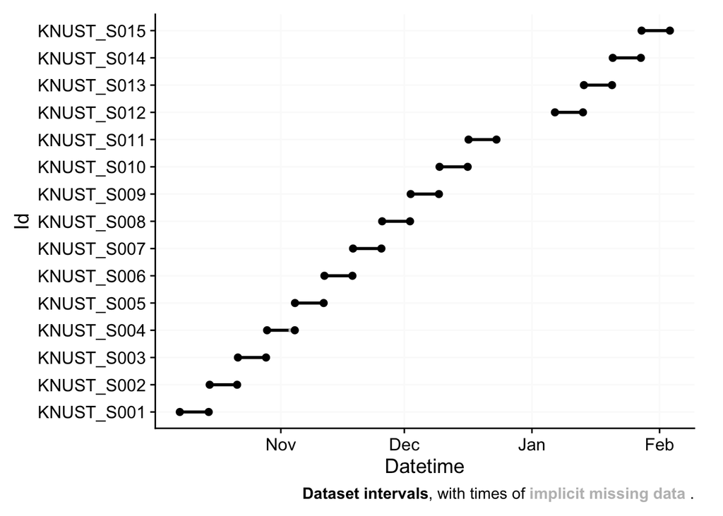

```r
data <- import$ActLumus(files, tz, auto.id = pattern)
```

## Regularizing data

```r
data |> has_gaps()
```

```
[1] TRUE
```

```r
data |> has_irregulars()
```

```
[1] TRUE
```

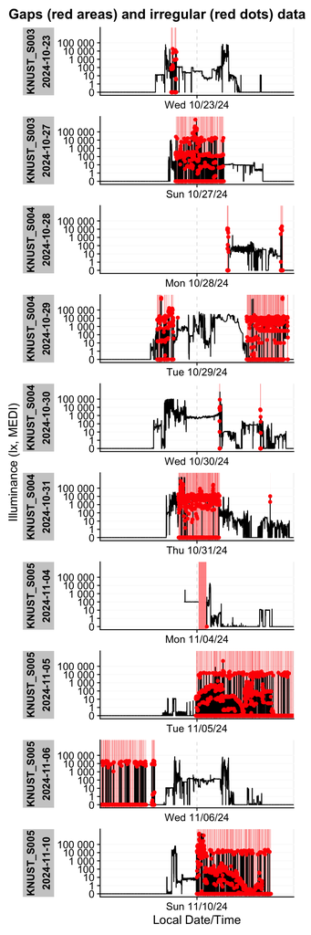

```r
data |> gg_gaps(group.by.days = TRUE, show.irregulars = TRUE, full.days = FALSE)
```

Apparently, `KNUST_S003`, `KNUST_S004`, and `KNUST_S005` suffer from some kind of defect, where the data become irregular and show values around 10^4 lx, even at night. We first bin the irregular data into the next regular interval, and then convert implicit to explicit days. We will further remove unreasonably high values above 100.000 lx melanopic EDI

```r
data_cleaned <-
  data |>
  aggregate_Datetime() |> #remove irregular data
  filter(MEDI <= 10^5) |> #remove high values
  gap_handler(full.days = TRUE) #remove implicit gaps

data_cleaned |> has_gaps() #no more implicit gaps
```

```
[1] FALSE
```

```r
data_cleaned |> has_irregulars() #no more irregular data
```

```
[1] FALSE
```

```r
data_cleaned |> gap_table()
```

Summary of available and missing data

Variable: melanopic EDI

|  | Data Regular Time | Data Regular % | Data Regular n<sup>1</sup> | Data Irregular n<sup>2,1</sup> | Data Range Time | Data Range n<sup>1</sup> | Data Interval Time | Missing Gaps N | Missing Gaps ø | Missing Gaps øn<sup>1</sup> | Missing Gaps Time | Missing Gaps % | Missing Gaps n<sup>1</sup> | Missing Implicit Time | Missing Implicit % | Missing Implicit n<sup>1</sup> | Missing Explicit Time | Missing Explicit % | Missing Explicit n<sup>1</sup> |
| --- | --- | --- | --- | --- | --- | --- | --- | --- | --- | --- | --- | --- | --- | --- | --- | --- | --- | --- | --- |
| **Overall** | 14w 1d 18h 36m 30s | 83.1%<sup>3</sup> | 862,059 | 0 | 17w 1d | 1,036,800 | 10 | 5,265 | 6d 19h 35m 8s | 58,891 | 2w 6d 5h 23m 30s | 16.9%<sup>3</sup> | 174,741 | 0s | 0.0%<sup>3</sup> | 0 | 2w 6d 5h 23m 30s | 16.9%<sup>3</sup> | 174,741 |
| KNUST_S001 |  |  |  |  |  |  |  |  |  |  |  |  |  |  |  |  |  |  |  |
|  | 1w 30m 20s | 87.8% | 60,662 | 0 | 1w 1d | 69,120 | 10s | 2 | 11h 44m 50s | 4,229 | 23h 29m 40s | 12.2% | 8,458 | 0s | 0.0% | 0 | 23h 29m 40s | 12.2% | 8,458 |
| KNUST_S002 |  |  |  |  |  |  |  |  |  |  |  |  |  |  |  |  |  |  |  |
|  | 6d 16h 7m 20s | 83.4% | 57,644 | 0 | 1w 1d | 69,120 | 10s | 3 | 10h 37m 33s | 3,825 | 1d 7h 52m 40s | 16.6% | 11,476 | 0s | 0.0% | 0 | 1d 7h 52m 40s | 16.6% | 11,476 |
| KNUST_S003 |  |  |  |  |  |  |  |  |  |  |  |  |  |  |  |  |  |  |  |
|  | 6d 19h 43m 20s | 85.3% | 58,940 | 0 | 1w 1d | 69,120 | 10s | 68 | 24m 57s | 150 | 1d 4h 16m 40s | 14.7% | 10,180 | 0s | 0.0% | 0 | 1d 4h 16m 40s | 14.7% | 10,180 |
| KNUST_S004 |  |  |  |  |  |  |  |  |  |  |  |  |  |  |  |  |  |  |  |
|  | 4d 23h 22m 10s | 62.2% | 42,973 | 0 | 1w 1d | 69,120 | 10s | 1937 | 2m 15s | 14 | 3d 37m 50s | 37.8% | 26,147 | 0s | 0.0% | 0 | 3d 37m 50s | 37.8% | 26,147 |
| KNUST_S005 |  |  |  |  |  |  |  |  |  |  |  |  |  |  |  |  |  |  |  |
|  | 6d 22m 40s | 75.2% | 51,976 | 0 | 1w 1d | 69,120 | 10s | 3235 | 53s | 5 | 1d 23h 37m 20s | 24.8% | 17,144 | 0s | 0.0% | 0 | 1d 23h 37m 20s | 24.8% | 17,144 |
| KNUST_S006 |  |  |  |  |  |  |  |  |  |  |  |  |  |  |  |  |  |  |  |
|  | 6d 19h 14m 10s | 85.0% | 58,765 | 0 | 1w 1d | 69,120 | 10s | 2 | 14h 22m 55s | 5,178 | 1d 4h 45m 50s | 15.0% | 10,355 | 0s | 0.0% | 0 | 1d 4h 45m 50s | 15.0% | 10,355 |
| KNUST_S007 |  |  |  |  |  |  |  |  |  |  |  |  |  |  |  |  |  |  |  |
|  | 6d 21h 23m 50s | 86.1% | 59,543 | 0 | 1w 1d | 69,120 | 10s | 2 | 13h 18m 5s | 4,788 | 1d 2h 36m 10s | 13.9% | 9,577 | 0s | 0.0% | 0 | 1d 2h 36m 10s | 13.9% | 9,577 |
| KNUST_S008 |  |  |  |  |  |  |  |  |  |  |  |  |  |  |  |  |  |  |  |
|  | 6d 18h 34m 10s | 84.7% | 58,525 | 0 | 1w 1d | 69,120 | 10s | 2 | 14h 42m 55s | 5,298 | 1d 5h 25m 50s | 15.3% | 10,595 | 0s | 0.0% | 0 | 1d 5h 25m 50s | 15.3% | 10,595 |
| KNUST_S009 |  |  |  |  |  |  |  |  |  |  |  |  |  |  |  |  |  |  |  |
|  | 6d 20h 39m 40s | 85.8% | 59,278 | 0 | 1w 1d | 69,120 | 10s | 2 | 13h 40m 10s | 4,921 | 1d 3h 20m 20s | 14.2% | 9,842 | 0s | 0.0% | 0 | 1d 3h 20m 20s | 14.2% | 9,842 |
| KNUST_S010 |  |  |  |  |  |  |  |  |  |  |  |  |  |  |  |  |  |  |  |
|  | 6d 20h 1m 50s | 85.4% | 59,051 | 0 | 1w 1d | 69,120 | 10s | 2 | 13h 59m 5s | 5,034 | 1d 3h 58m 10s | 14.6% | 10,069 | 0s | 0.0% | 0 | 1d 3h 58m 10s | 14.6% | 10,069 |
| KNUST_S011 |  |  |  |  |  |  |  |  |  |  |  |  |  |  |  |  |  |  |  |
|  | 6d 18h 32m 20s | 84.7% | 58,514 | 0 | 1w 1d | 69,120 | 10s | 2 | 14h 43m 50s | 5,303 | 1d 5h 27m 40s | 15.3% | 10,606 | 0s | 0.0% | 0 | 1d 5h 27m 40s | 15.3% | 10,606 |
| KNUST_S012 |  |  |  |  |  |  |  |  |  |  |  |  |  |  |  |  |  |  |  |
|  | 6d 19h 25m 20s | 85.1% | 58,832 | 0 | 1w 1d | 69,120 | 10s | 2 | 14h 17m 20s | 5,144 | 1d 4h 34m 40s | 14.9% | 10,288 | 0s | 0.0% | 0 | 1d 4h 34m 40s | 14.9% | 10,288 |
| KNUST_S013 |  |  |  |  |  |  |  |  |  |  |  |  |  |  |  |  |  |  |  |
|  | 6d 19h 54m 20s | 85.4% | 59,006 | 0 | 1w 1d | 69,120 | 10s | 2 | 14h 2m 50s | 5,057 | 1d 4h 5m 40s | 14.6% | 10,114 | 0s | 0.0% | 0 | 1d 4h 5m 40s | 14.6% | 10,114 |
| KNUST_S014 |  |  |  |  |  |  |  |  |  |  |  |  |  |  |  |  |  |  |  |
|  | 6d 19h 44m 50s | 85.3% | 58,949 | 0 | 1w 1d | 69,120 | 10s | 2 | 14h 7m 35s | 5,086 | 1d 4h 15m 10s | 14.7% | 10,171 | 0s | 0.0% | 0 | 1d 4h 15m 10s | 14.7% | 10,171 |
| KNUST_S015 |  |  |  |  |  |  |  |  |  |  |  |  |  |  |  |  |  |  |  |
|  | 6d 21h 10s | 85.9% | 59,401 | 0 | 1w 1d | 69,120 | 10s | 2 | 13h 29m 55s | 4,860 | 1d 2h 59m 50s | 14.1% | 9,719 | 0s | 0.0% | 0 | 1d 2h 59m 50s | 14.1% | 9,719 |

<sup>1</sup> Number of (missing or actual) observations  
<sup>2</sup> If n > 0: it is possible that the other summary statistics are affected, as they are calculated based on the most prominent interval.  
<sup>3</sup> Based on times, not necessarily number of observations

# Dealing with measurement spikes

Measurement spikes seem to happen at random during certain periods of time. We can capture those by treating them as clusters of at maximum 2 epochs length. The next step visualizes this approach for `KNUST_S005`.

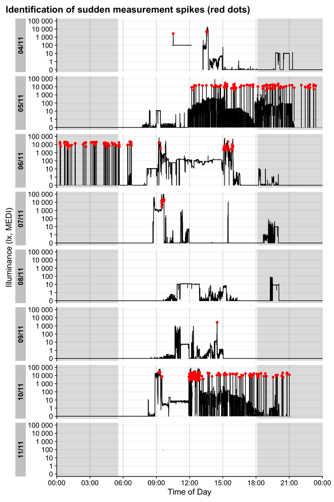

```r
data_cleaned |>
  filter(Id == "KNUST_S005") |>
  add_clusters(
    MEDI > 2000 & MEDI < 30000,
    cluster.duration = "20 secs",
    duration.type = "max"
  ) |>
  gg_day(geom = "line") |>
  gg_photoperiod(coordinates) +
  geom_point(data = \(x) filter(x, !is.na(state)), col = "red") +
  labs(title = "Identification of sudden measurement spikes (red dots)")
```

We assess how many there are across the participants:

```r
data_cleaned |>
  extract_clusters(
    MEDI > 2000 & MEDI < 30000,
    cluster.duration = "20 secs",
    duration.type = "max",
    add.label = TRUE
  ) |>
  group_by(label, Id) |>
  summarize_numeric() |>
  select(Id, label, episodes) |>
  group_by(label) |>
  gt() |>
  tab_header("Measurement spikes")
```

Measurement spikes

| Id | episodes |
| --- | --- |
| MEDI>2000&MEDI<30000\|d≤20secs |  |
| KNUST_S001 | 95 |
| KNUST_S002 | 37 |
| KNUST_S003 | 89 |
| KNUST_S004 | 1062 |
| KNUST_S005 | 309 |
| KNUST_S006 | 108 |
| KNUST_S007 | 270 |
| KNUST_S008 | 42 |
| KNUST_S009 | 148 |
| KNUST_S010 | 62 |
| KNUST_S011 | 200 |
| KNUST_S012 | 232 |
| KNUST_S013 | 202 |
| KNUST_S014 | 98 |
| KNUST_S015 | 112 |

Spikes are detected for every Id. We will not remove the data, but rather replace them with the value 2 intervals prior. This ensures plausible values for that time and avoids that a spike is copied over.

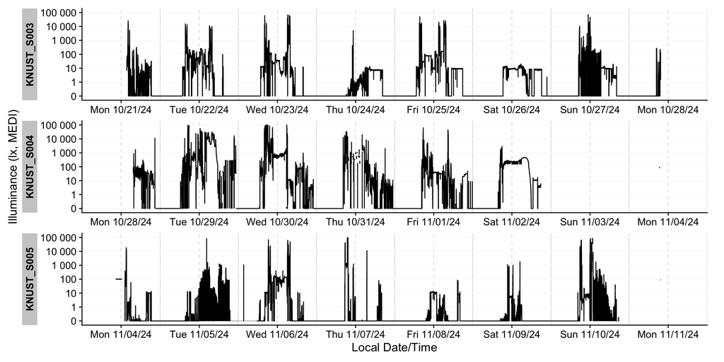

```r
data_cleaned <-
  data_cleaned |>
  add_clusters(
    MEDI > 2000 & MEDI < 30000,
    cluster.duration = "20 secs",
    duration.type = "max"
  ) |>
  mutate(MEDI = ifelse(!is.na(state), lag(MEDI, 2), MEDI))

data_cleaned |>
  filter(Id %in% c("KNUST_S003", "KNUST_S004", "KNUST_S005")) |>
  gg_days()
```

These data now look sensible enough for further visualization and processing.

## Visualization

### Overview

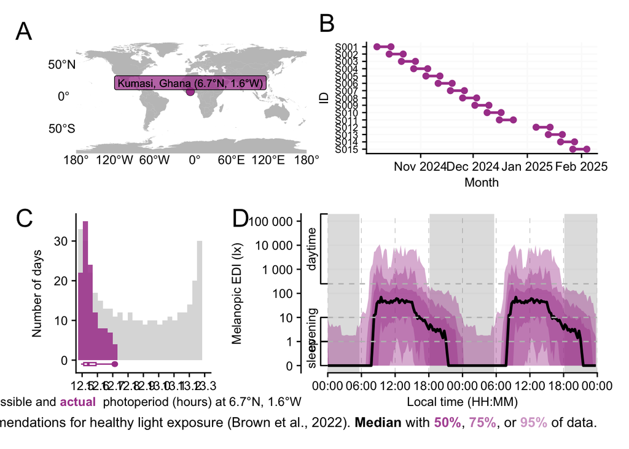

```r
data_cleaned |>
  mutate(Id = Id |> fct_relabel(\(x) str_remove(x, "KNUST_"))) |>
  grand_overview(
    coordinates,
    "Kumasi",
    "Ghana",
    country_colors,
    photoperiod_sequence = 0.1
  )
```

```r
ggsave(
  here("output/figures/Figure_1.png"),
  width = 17,
  height = 10,
  scale = 2,
  units = "cm"
)
ggsave(
  here("output/figures/Figure_1.jpeg"),
  width = 17,
  height = 10,
  scale = 2,
  units = "cm"
)
```

## Stats

### Summary table

```r
table_summary <-
light_summary_table(
  data_cleaned, coordinates, "Kumasi", "Ghana", country_colors["Ghana"],
  histograms = TRUE
)

table_summary
```

Summary table

| Overview |  |  |  |  |
| --- | --- | --- | --- | --- |
| Participants |  | **15** |  |  |
| Participant-days |  | **120** |  |  |
| Days ≥80% complete |  | **88** |  |  |
| Missing/irregular |  | **16.88%** (12.24% - 37.92%) |  |  |
| Photoperiod |  | **12h 33m** (12h 29m - 12h 42m) |  | <sup>1</sup> |
| Metrics<sup>2</sup> |  |  |  |  |
| Dose | D (lx·h) | **10,307** ±12,469 (28 - 60,588) |  |  |
| Duration above 250 lx | TAT<sub>250</sub> | **1h 43m** ±1h 49m (0s - 7h 45m) |  |  |
| Duration within 1-10 lx | TWT<sub>1–10</sub> | **3h 22m** ±2h 33m (14m - 13h 19m) |  |  |
| Duration below 1 lx | TBT<sub>1</sub> | **12h 48m** ±3h 35m (4h 8m - 22h 43m) |  |  |
| Period above 250 lx | PAT<sub>250</sub> | **28m 12s** ±38m 22s (0s - 4h 6m) |  |  |
| Duration above 1000 lx | TAT<sub>1000</sub> | **56m 58s** ±1h 4m (0s - 5h 11m) |  |  |
| First timing above 250 lx | FLiT<sub>250</sub> | **08:59** ±02:00 (01:38 - 15:05) |  | <sup>1</sup> |
| Mean timing above 250 lx | MLiT<sub>250</sub> | **12:07** ±01:36 (08:30 - 15:55) |  | <sup>1</sup> |
| Last timing above 250 lx | LLiT<sub>250</sub> | **16:30** ±02:55 (08:53 - 23:16) |  | <sup>1</sup> |
| Brightest 10h midpoint | M10<sub>midpoint</sub> | **13:05** ±01:58 (04:59 - 18:59) |  | <sup>1</sup> |
| Darkest 5h midpoint | L5<sub>midpoint</sub> | **03:38** ±04:15 (02:29 - 23:35) |  | <sup>1</sup> |
| Brightest 10h mean<sup>3</sup> | M10<sub>mean</sub> (lx) | **71.1** ±118.8 (0.1 - 838.7) |  |  |
| Darkest 5h mean<sup>3</sup> | L5<sub>mean</sub> (lx) | **0.0** ±0.0 (0.0 - 0.2) |  |  |
| Interdaily stability | IS | **0.276** ±0.062 (0.162 - 0.364) |  |  |
| Intradaily variability | IV | **1.390** ±0.399 (0.636 - 1.923) |  |  |

values show: **mean** ±sd (min - max) and are all based on measurements of melanopic EDI (lx)  
<sup>1</sup> Histogram limits are set from 00:00 to 24:00  
<sup>2</sup> Metrics are calculated on a by-participant-day basis (n=88) with the exception of IV and IS, which are calculated on a by-participant basis (n=15).  
<sup>3</sup> Values were log 10 transformed prior to averaging, with an offset of 0.1, and backtransformed afterwards

```r
gtsave(table_summary, here("output/tables/table_summary.png"), vwidth = 850)
gtsave(table_summary, here("output/tables/table_summary.pdf"))
# gtsave(table_summary |> cols_hide(c(plot, footnote)), here("output/tables/table_summary.docx"))
```